# Deep Learning

Session 4: Regularization, Normalization, Optimizers and Over-parametrization

David Picard

2026-11-16

# Welcome

## Session 4: Agenda

8:30–11:30 · 180 min

| Time | Block |
| --- | --- |
| 8:30–8:35 | Recap: where we left off |
| 8:35–8:55 | Regularization: weight decay and dropout |
| 8:55–9:25 | Normalization: BatchNorm, LayerNorm and Adaptive LayerNorm |
| 9:25–9:45 | Optimizers: SGD with momentum and Adam |
| 9:45–9:50 | Learning rate schedules |
| 9:50–10:10 | ⚡ Coding exercise: weight decay and Adam |
| 10:10–10:25 | ☕ Break |
| 10:25–10:40 | Over-parametrization and double descent |
| 10:40–10:55 | Lazy training and the lottery ticket |
| 10:55–11:05 | Scaling laws |
| 11:05–11:25 | ⚡ Coding exercise: a mini scaling law |
| 11:25–11:30 | Wrap-up |

## Where we left off

- Session 3: perceptrons, backprop, MLPs, CNNs, ResNet
- A network that is deep enough and wide enough can fit almost anything
- Today: the tricks that make a deep network actually *train* well, and why making it bigger often helps instead of just overfitting

# Regularization

0:05–0:25 · 20 min

## Why regularize a neural network

- A loss that never vanishes (cross-entropy on correctly classified samples still has gradient) keeps reinforcing the same correlated weights
- Weights inflated this way can destabilize training, or crowd out correlations with smaller but still useful activations
- Two standard fixes: shrink the weights directly, or make the network unable to rely on any single feature

## Weight decay

Shrink every weight a little at each step, independently of the loss,

$$w_i \leftarrow (1 - \lambda_w)\, w_i$$

- Equivalent to an $\ell_2$ penalty on the weights, the neural network analog of ridge regression
- Watch the interaction with the optimizer: this is *not* the same as adding $\lambda_w \|w\|_2^2$ to the loss once the optimizer normalizes gradients (Adam, later today)

## Weight decay against overfitting

[interactive chart not shown]

weight decay = 0.60

## Dropout

Randomly zero a fraction of a layer’s input to stop a neuron from relying on one specific feature,

$$x_{i+1} = f_i(x_i \circ a_i), \qquad a_i \sim \text{Bernoulli}(1-p)$$

- **Train**: survivors rescaled by $1/(1-p)$ so the input stays correct in expectation (*inverted dropout*)
- **Eval**: dropout turned off, no rescaling needed
- Leaving dropout on at test time turns the output into a random variable: a cheap pseudo-ensemble that flags samples the network is unsure about

## Dropout against overfitting

[interactive chart not shown]

dropout p = 0.20

*32-32-wide ReLU MLP trained on 8 noisy points: plenty of capacity to memorize the noise.

## Dropout in PyTorch

```python
class Dropout(nn.Module):
    def __init__(self, p=0.5):
        super().__init__()
        self.p = p  # drop probability
    def forward(self, x):
        if self.training:
            mask = torch.bernoulli(torch.full_like(x, 1 - self.p))
            return x * mask / (1 - self.p)
        return x
```

*Inverted-dropout convention: zero with probability $p$ and rescale survivors by $1/(1-p)$ at train time, so `eval()` needs no change at all.*

# Normalization

0:25–0:55 · 30 min

## Why normalize

- Backprop creates a positive feedback loop: a weight that helps the decision gets reinforced, which can grow activations without bound
- A layer’s input distribution also keeps shifting as the layers *below* it keep training (BatchNorm’s *covariate shift*)
- Fix: force the input of a layer to have a controlled mean and variance, with a learned affine transform to put back whatever scale and offset the network actually needs

## BatchNorm

Normalize each feature across the batch,

$$\text{BN}(x_i) = \gamma \frac{x_i - \mu}{\sqrt{\sigma^2 + \epsilon}} + \beta$$

- $\mu, \sigma^2$: mean and variance of $x_i$ *over the batch*, tracked at train time with an exponential moving average for use at test time
- Couples samples in a batch together $\Rightarrow$ struggles with a small batch size, and the training/test statistics gap can hurt under domain shift

## LayerNorm

Normalize each sample across its own features instead,

$$\text{LN}(x_i) = \gamma \frac{x_i - \mu}{\sqrt{\sigma^2 + \epsilon}} + \beta$$

- $\mu, \sigma^2$ computed over the *last dimension* of a single sample: no coupling across the batch, no running statistics, train and eval use the exact same computation
- $\gamma, \beta$ are optional (could be absorbed by the surrounding layers), but let every other layer ignore the signal’s scale entirely

## Comparing BatchNorm and LayerNorm

[interactive chart not shown]

*Same (batch x feature) grid of raw activations, normalized along a different axis. The highlighted strip is one group: everything in it shares a single mean and std.*

## Adaptive LayerNorm

- Instead of learning $\gamma, \beta$ directly, make them the *output of a small network* fed with some auxiliary signal
- E.g. for image generation (next chapter), conditioning on “what class to generate” steers the whole signal through every layer
- Solves a different problem than covariate shift: controllable conditioning, not training stability

## BatchNorm in PyTorch

```python
class BatchNorm(nn.Module):
    def __init__(self, n_features, eps=1e-5, eta=0.999):
        super().__init__()
        self.eps, self.eta = eps, eta
        self.gamma = nn.Parameter(torch.ones(n_features))
        self.beta = nn.Parameter(torch.zeros(n_features))
        self.register_buffer("running_mean", torch.zeros(n_features))
        self.register_buffer("running_var", torch.ones(n_features))
    def forward(self, x):
        # x: (batch, n_features)
        if self.training:
            mean, var = x.mean(dim=0), x.var(dim=0, unbiased=False)
            with torch.no_grad():
                self.running_mean = self.eta * self.running_mean + (1 - self.eta) * mean
                self.running_var = self.eta * self.running_var + (1 - self.eta) * var
        else:
            mean, var = self.running_mean, self.running_var
        x_hat = (x - mean) / torch.sqrt(var + self.eps)
        return self.gamma * x_hat + self.beta
```

## LayerNorm in PyTorch

```python
class LayerNorm(nn.Module):
    def __init__(self, n_features, eps=1e-5):
        super().__init__()
        self.eps = eps
        self.gamma = nn.Parameter(torch.ones(n_features))
        self.beta = nn.Parameter(torch.zeros(n_features))
    def forward(self, x):
        # x: (..., n_features); statistics over the last dimension only
        mean = x.mean(dim=-1, keepdim=True)
        var = x.var(dim=-1, unbiased=False, keepdim=True)
        x_hat = (x - mean) / torch.sqrt(var + self.eps)
        return self.gamma * x_hat + self.beta
```

*No running buffers at all: every statistic comes from the current sample.*

# Optimizers

0:55–1:15 · 20 min

## Beyond vanilla SGD

- Deep networks have more parameters than fit in a mini-batch, so most gradients are noisy estimates of rare features
- Gradient accumulation (summing several mini-batches before stepping) works, but is slow: updates become less frequent
- Instead, buffer the gradient history itself and update from the buffer

## SGD with momentum

Follow a newtonian analogy: the gradient is a force, it updates a velocity, and the weights move by their velocity,

$$v_\theta \leftarrow m\, v_\theta + g, \qquad
w_\theta \leftarrow w_\theta - \eta\, v_\theta$$

- At a constant gradient, the velocity’s magnitude saturates around $1/(1-m)$: the learning rate must account for that amplification
- Cheap: one extra buffer per parameter

## SGD with momentum in PyTorch

```python
class SGDMomentum(torch.optim.Optimizer):
    def __init__(self, params, lr=1e-2, momentum=0.9):
        super().__init__(params, dict(lr=lr, momentum=momentum))
    @torch.no_grad()
    def step(self):
        for group in self.param_groups:
            lr, m = group["lr"], group["momentum"]
            for p in group["params"]:
                if p.grad is None:
                    continue
                state = self.state[p]
                if "velocity" not in state:
                    state["velocity"] = torch.zeros_like(p)
                v = state["velocity"]
                v.mul_(m).add_(p.grad)
                p.add_(v, alpha=-lr)
```

## Adam

Momentum is slow on flat regions of the loss. Adam tracks the *squared* gradient too, and divides the step by its square root: small gradients get amplified while large ones get damped,

$$m \leftarrow \beta_1 m + (1-\beta_1) g, \qquad
v \leftarrow \beta_2 v + (1-\beta_2) g^2$$
$$w \leftarrow w - \eta\, \frac{\hat m}{\sqrt{\hat v} + \epsilon}$$

with $\hat m, \hat v$ the bias-corrected moments ($/(1-\beta_i^t)$, needed because $m, v$ start at zero).

## Adam in PyTorch

```python
class Adam(torch.optim.Optimizer):
    def __init__(self, params, lr=1e-3, betas=(0.9, 0.999), eps=1e-8):
        super().__init__(params, dict(lr=lr, betas=betas, eps=eps))
    @torch.no_grad()
    def step(self):
        for group in self.param_groups:
            lr, (beta1, beta2), eps = group["lr"], group["betas"], group["eps"]
            for p in group["params"]:
                if p.grad is None:
                    continue
                state = self.state[p]
                if "t" not in state:
                    state["t"] = 0
                    state["m"] = torch.zeros_like(p)
                    state["v"] = torch.zeros_like(p)
                state["t"] += 1
                t, m, v = state["t"], state["m"], state["v"]
                m.mul_(beta1).add_(p.grad, alpha=1 - beta1)
                v.mul_(beta2).addcmul_(p.grad, p.grad, value=1 - beta2)
                m_hat = m / (1 - beta1 ** t)
                v_hat = v / (1 - beta2 ** t)
                p.addcdiv_(m_hat, v_hat.sqrt().add_(eps), value=-lr)
```

*Adam is the de facto standard, despite a flawed original convergence proof: it provably converges under $0 \le \beta_1 < \beta_2 < 1$.*

## Watching three optimizers race

[interactive chart not shown]

learning rate = 1.0x

# Learning Rate Schedules

1:15–1:20 · 5 min

## Warmup and cosine decay

- Constant learning rate: fast early, but unstable by the end of training
- Warmup: ramp the learning rate up linearly for the first few hundred steps, empirically stable even for a high peak rate
- Then decay it, following a cosine curve down to a small floor value
- Downside: needs the total step count fixed in advance, which is exactly what a scaling law (later today) is for

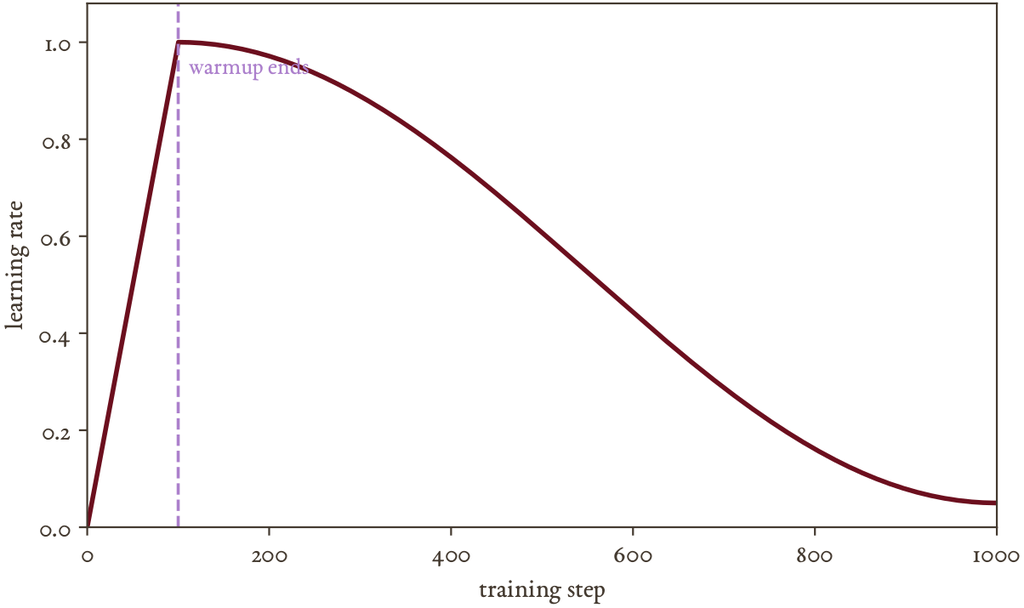

Linear warmup into a cosine decay: the learning rate ramps up over the first 100 steps, then follows a cosine curve down to a small floor by step 1000.

## Racing under the schedule

[interactive chart not shown]

peak learning rate = 15.0x warmup steps = 0

# Coding Exercise: Weight Decay and Adam

1:20–1:40 · 20 min

## Step 1: set up the overfitting problem

Same toy problem (8 noisy points from $\sin(2.5x)$), but now you train it yourself.

```python
import torch, torch.nn as nn
torch.manual_seed(0)

def make_mlp():
    return nn.Sequential(
        nn.Linear(1, 64), nn.ReLU(),
        nn.Linear(64, 64), nn.ReLU(),
        nn.Linear(64, 1),
    )

def target_fn(x):
    return torch.sin(2.5 * x)

g = torch.Generator().manual_seed(16)
x_train = torch.empty(8, 1).uniform_(-1, 1, generator=g)
y_train = target_fn(x_train) + 0.25 * torch.randn(8, 1, generator=g)
x_val = torch.linspace(-1, 1, 200).unsqueeze(1)
y_val = target_fn(x_val)

def train(optimizer_fn, epochs=1500):
    torch.manual_seed(0)  # same init every call, only the optimizer differs
    model = make_mlp()
    opt = optimizer_fn(model.parameters())
    for step in range(epochs):
        opt.zero_grad()
        loss = ((model(x_train) - y_train) ** 2).mean()
        loss.backward()
        opt.step()
    with torch.no_grad():
        train_loss = ((model(x_train) - y_train) ** 2).mean().item()
        val_loss = ((model(x_val) - y_val) ** 2).mean().item()
    return train_loss, val_loss

print(train(lambda p: torch.optim.SGD(p, lr=0.3), epochs=3000))
# -> roughly (0.04, 0.16): low training loss, much higher validation loss
```

Run it. Confirm you see the same overfitting gap as in the figures.

## Step 2: weight decay fixes it, for SGD

Add `weight_decay` to the SGD call and sweep a few values:

```python
for wd in [0.0, 0.01, 0.02, 0.05]:
    tr, va = train(lambda p: torch.optim.SGD(p, lr=0.3, weight_decay=wd), epochs=3000)
    print(f"wd={wd:<5} train={tr:.4f} val={va:.4f}")
```

`weight_decay` here is exactly the $w \leftarrow (1-\lambda_w) w$ rule from the slides: for plain SGD it’s mathematically identical to adding an $\ell_2$ penalty to the loss. You should see validation loss drop by roughly 3x around `wd=0.01`, with training loss barely moving. Good, regularization working as advertised.

## Step 3: the same fix, now under Adam

Swap the optimizer for Adam, keeping the exact same `weight_decay` API, and sweep a wider range (Adam needs a smaller learning rate):

```python
for wd in [0.0, 0.01, 0.1, 0.3, 0.6, 1.0]:
    tr, va = train(lambda p: torch.optim.Adam(p, lr=0.01, weight_decay=wd), epochs=1500)
    print(f"wd={wd:<5} train={tr:.4f} val={va:.4f}")
```

At `wd=0` it overfits even harder than SGD did (training loss hits exactly 0). Small `wd` still helps, but keep turning it up the way you just did for SGD and, somewhere around `wd=0.3-0.6`, both losses collapse together to roughly the same bad value rather than training loss gracefully rising: the model has stopped fitting almost anything. `torch.optim.Adam`’s `weight_decay` adds $\lambda_w w$ to the *gradient*, so it goes through Adam’s own per-parameter normalization ($g^2$, $\sqrt{\hat v}$) instead of shrinking every weight by the fixed fraction the formula promises. That’s the coupling problem.

## Step 4: decouple it

Switch `torch.optim.Adam` for `torch.optim.AdamW`, same arguments, same sweep:

```python
for wd in [0.0, 0.3, 0.6, 1.0, 2.0, 5.0]:
    tr, va = train(lambda p: torch.optim.AdamW(p, lr=0.01, weight_decay=wd), epochs=1500)
    print(f"wd={wd:<5} train={tr:.4f} val={va:.4f}")
```

No collapse this time: validation loss improves smoothly over a much wider range of `wd`, reaching a better minimum than coupled Adam ever did before it broke. `AdamW` applies the decay directly to the parameter, after the Adam step, exactly like the $w \leftarrow (1-\lambda_w) w$ rule: the update that goes through $\sqrt{\hat v}$ is only the gradient term.

**If you have time:** drop `AdamW` and instead add one line after `opt.step()` to a plain `Adam` run,

```python
with torch.no_grad():
    for p in model.parameters():
        p.mul_(1 - lr * wd)
```

and check it reproduces AdamW’s numbers. This is the exact formula from the Weight Decay slide, applied by hand.

# Break

1:40–1:55 · 15 min

## ☕ 15-minute break

# Over-parametrization

1:55–2:10 · 15 min

## A paradox on paper

- Our generalization bounds only hold for low-complexity hypothesis classes, yet the empirical trend in deep learning is that bigger is better
- A bound is a guarantee of success, not a proof of failure: violating its conditions does not mean the predictor *must* fail, just that we no longer have a guarantee either way
- So what actually happens once a network is large enough to fit the training data exactly, and then some?

## Double descent

Train a ridge regression on an increasing number of random Fourier features, on a problem that is genuinely non-linear but has very few training samples:

- Loss first decreases as expected (SRM), since more features mean less bias
- It then spikes exactly when the number of features equals the number of training samples, the **interpolation threshold**, where the fit is forced to be *exactly* right and any noise gets fully absorbed
- Past that threshold, loss decreases *again*: more features means more equally-good interpolating solutions, and the minimum-norm one among them is the one SGD finds

## Interpolation threshold

[interactive chart not shown]

*A ridge regression fit with an increasing number $D$ of random Fourier features, on a target itself built from 100 such features (so more features always means less bias). Validation loss spikes right at $D = n_{\text{train}}$, then descends again.*

# Lazy Training and the Lottery Ticket

2:10–2:25 · 15 min

## Lazy training

- Take the smallest network solving a toy problem (3 hidden neurons) and give it many more (say 64). How does training behave?
- Wider networks travel a *shorter* relative distance from their initialization, while converging more reliably

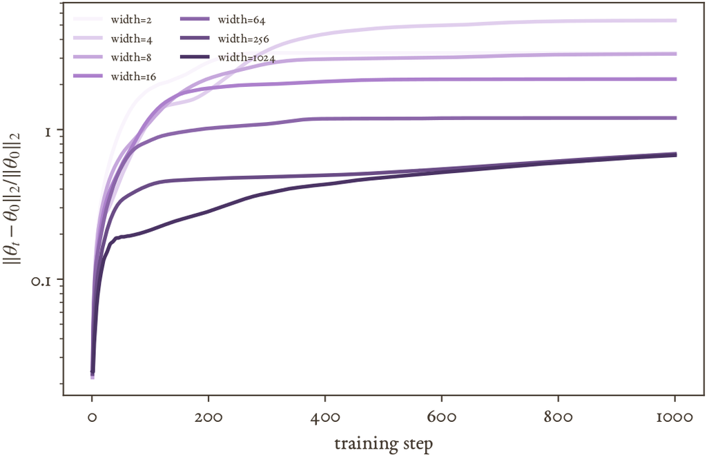

Relative distance traveled by the parameters during training. Wide networks barely move from their initialization even as the loss converges.

## The Neural Tangent Kernel

Linearize the loss around the initialization,

$$l_x(w) \approx l_x(w_0) + \nabla l_x(w_0)^\top (w - w_0)$$

- This is a *linear* model in the mapping $\phi(x) = \nabla l_x(w_0)$: the **Neural Tangent Kernel**, increasingly accurate as width grows
- Some weights are highly influential, others are near-blind-spots of the kernel and barely move: only the useful ones need to change
- A wide network doesn’t need luck to find a good solution: it just needs enough neurons that a few of them already point the right way

## The Lottery Ticket Hypothesis

A randomly-initialized dense network contains a sub-network that, trained in isolation from its *original* initialization, matches the full network’s accuracy:

## Pruning down to the winning ticket

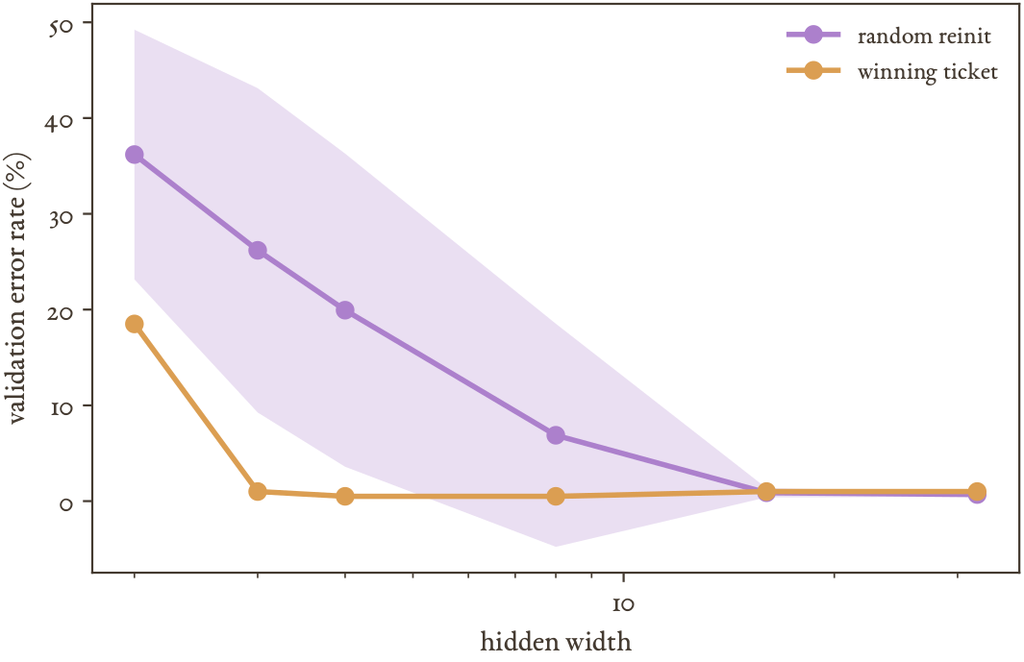

## Winning ticket vs. random luck

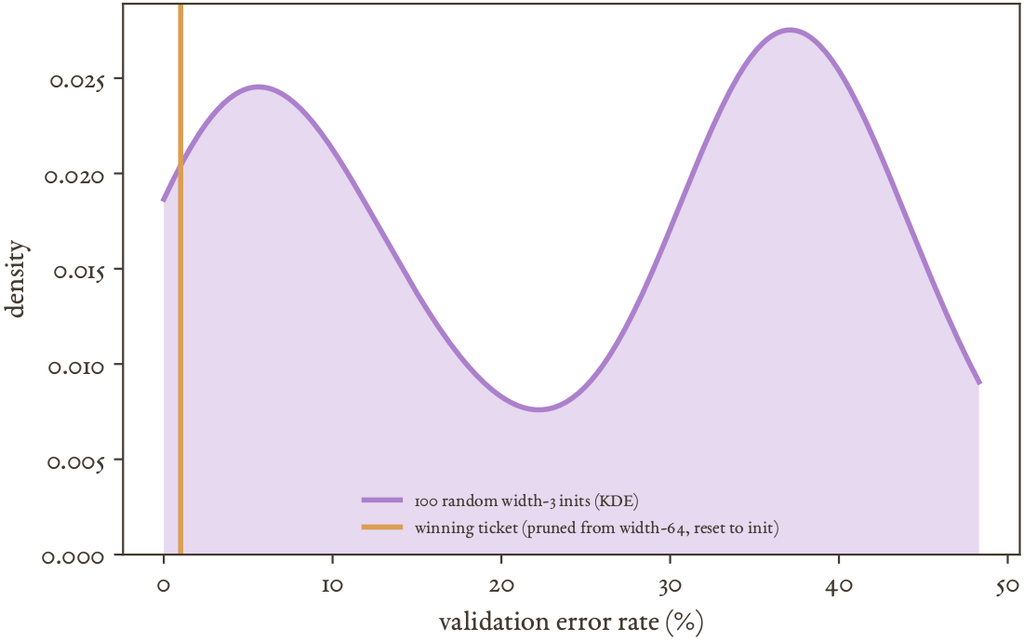

*Over-parametrization gives the initialization more draws at useful neurons (lottery ticket); NTK means the unlucky draws barely get touched and don’t hurt; redundant neurons are what double descent turns into a generalization benefit instead of overfitting.*

# Scaling Laws

2:25–2:35 · 10 min

## How big should a network be

- Bigger costs more compute, and can cross the interpolation threshold depending on how much data is available: is the extra cost worth it?
- Fit a power law relating validation loss to compute, model size and dataset size, and use it to predict the best trade-off *before* paying for the full-scale run

## A scaling law on Bluebell

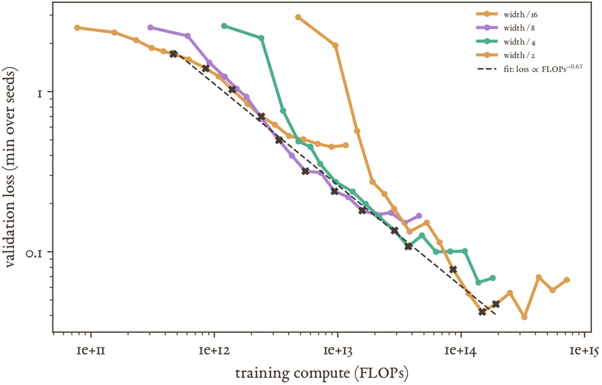

*Smaller models are the efficient choice at a small budget; past a point, continuing to train a small model wastes compute that a bigger model would spend better.*

# Coding Exercise: a Mini Scaling Law

2:35–2:55 · 20 min

## ⚡ Fit your own scaling law

Train 3 widths of a small MLP on a toy regression problem, across a ladder of compute budgets (number of gradient steps), and find the compute-optimal frontier.

```python
import torch, torch.nn as nn

def make_mlp(width):
    return nn.Sequential(
        nn.Linear(1, width), nn.ReLU(),
        nn.Linear(width, width), nn.ReLU(),
        nn.Linear(width, 1),
    )

def target_fn(x):
    return torch.sin(3 * x) + 0.3 * x

WIDTHS = [4, 16, 64]
BUDGETS = [20, 50, 100, 200, 400, 800]  # gradient steps

x_train = torch.linspace(-3, 3, 64).unsqueeze(1)
y_train = target_fn(x_train) + 0.05 * torch.randn_like(x_train)
x_val = torch.linspace(-3, 3, 200).unsqueeze(1)
y_val = target_fn(x_val)

results = {}  # (width, budget) -> validation MSE
for width in WIDTHS:
    model = make_mlp(width)
    opt = torch.optim.Adam(model.parameters(), lr=1e-2)
    for step in range(1, max(BUDGETS) + 1):
        # TODO: one training step (zero_grad, forward, MSE loss,
        # backward, opt.step)
        if step in BUDGETS:
            with torch.no_grad():
                # TODO: record results[(width, step)] = validation MSE
                pass
```

## ⚡ Fit your own scaling law (continued)

Once `results` is filled in:

```python
import matplotlib.pyplot as plt

flops_per_step = {4: 1, 16: 4, 64: 16}  # relative, not exact
frontier = {}
for (width, budget), mse in results.items():
    compute = flops_per_step[width] * budget
    # TODO: keep only the best (lowest-mse) width at each compute level
    # to build the compute-optimal frontier: frontier[compute] = min(...)

plt.loglog(sorted(frontier), [frontier[c] for c in sorted(frontier)], "o-")
plt.xlabel("compute (relative FLOPs)"); plt.ylabel("validation MSE")
```

Does a wider model ever lose to a narrower one at the same compute budget? At what budget does the 64-wide model start to pull ahead?

# Wrap-up

2:55–3:00 · 5 min

## Recap

- **Regularization**: weight decay and dropout keep a network from leaning on spurious correlations
- **Normalization**: BatchNorm and LayerNorm stabilize training along different axes; adaptive LayerNorm repurposes the same mechanism for conditioning
- **Optimizers**: momentum buffers the gradient, while Adam also normalizes by its own scale; both need a learning rate schedule to land well
- **Over-parametrization**: double descent, lazy training and the lottery ticket all point the same way: bigger networks are not just memorizing, they are easier to optimize and more likely to contain a good solution
- **Scaling laws**: predict the best size for a budget before spending it

## Next session

Chapter 8: sequence modeling, with RNNs, attention, and the transformer.